# R Notebook

### WEEK II

#### CLASSIFICATION

In the previous notebook, we covered linear regression as a tool that predicts a continuous y outcome. In this notebook, we will learn and practice how to predict a categorical or discrete outcome as a function of the dependent variables using the logistic regression method.

In a logistic regression model, the predicted outcome is a probability, which we can use to arrive at the - probability of a categorical event taking place i.e. political candidate A, B, or C coming on top of election results or -the probability of binary outcome of an event happening.

**The logit function**

In its essence, logistic regression predicts a probability that take on a value between 0 and 1. Logistic regression works with the inverse of the logit function, or the sigmoid function.
$$\begin{equation}
p = \frac{1}{1 + e^{-(\beta_0 + \beta_1 x_1 + \beta_2 x_2 + \cdots +
\beta_n x_n)}}
\end{equation}$$

**Estimating the parameters**

Recall that linear regression uses the OLS approach to estimate coefficients. In logistic regression, we use the **Maximum Likelihood Estimation** method to figure out the coefficients, which we then use to calculate probabilities.

In R, we will use the `glm` package to fit a logistic regression model to our data. But before we do that, let’s have a cursory look at the dataset first.

### First look at the dataset

```r
rm(list = ls())
```

```r
# load the default dataset
default_data <- ISLR2::Default
summary(default_data)
```

```
 default    student       balance           income
 No :9667   No :7056   Min.   :   0.0   Min.   :  772
 Yes: 333   Yes:2944   1st Qu.: 481.7   1st Qu.:21340
                       Median : 823.6   Median :34553
                       Mean   : 835.4   Mean   :33517
                       3rd Qu.:1166.3   3rd Qu.:43808
                       Max.   :2654.3   Max.   :73554
```

```r
str(default_data)
```

```
'data.frame':   10000 obs. of  4 variables:
 $ default: Factor w/ 2 levels "No","Yes": 1 1 1 1 1 1 1 1 1 1 ...
 $ student: Factor w/ 2 levels "No","Yes": 1 2 1 1 1 2 1 2 1 1 ...
 $ balance: num  730 817 1074 529 786 ...
 $ income : num  44362 12106 31767 35704 38463 ...
```

Our dataset contains two numerical and two factor variables. In this exercise we are interested in predicting those who default among customers. Let’s visualize the data as two separate boxplots exploring default balance and income of customers by default status.

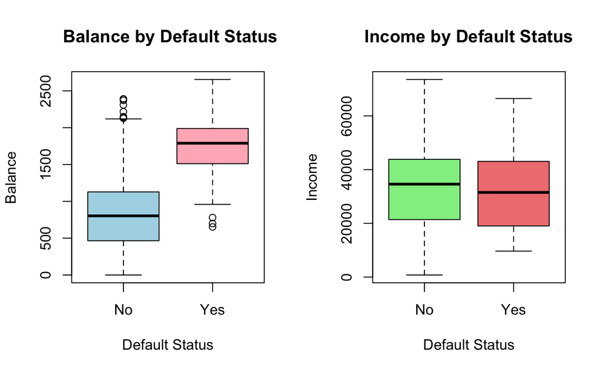

```r
# first set up the plot grid using par() function
par(mfrow = c(1, 2))

# boxplot for balance vs. default status
boxplot(balance ~ default, data = default_data,
        main = " Balance by Default Status",
        xlab = "Default Status", ylab = "Balance",
        col = c("lightblue", "lightpink"))

# boxplot for income vs. default status
boxplot(income ~ default, data = default_data,
        main = "Income by Default Status",
        xlab = "Default Status", ylab = "Income",
        col = c("lightgreen", "lightcoral"))
```

What do these boxplots tell us about the distribution of the default data? Income level of a customer does not play a big part in whether of not the customer defaults. Median income level both those who default and those who not are on par, and interquartile ranges of both groups are similar. There is more variance in default status if we consider bank balance as a predictor.

### Setting up the model

Let’s move on to modelling the default status of customers using their bank balance. We will now split the data into train and test, set up logistic regression and train our model.

```r
# set up the train-test split
n <- nrow(default_data)
n_train <- 7000 # take 70 percent of the total dataset for training
n_test <- 3000 # remaining 30 percent will be for testing
```

```r
# set seed for reproducibility
set.seed(1)
train_sample <- sample(n, n_train)
train_data <-default_data[train_sample,]
test_data <-default_data[-train_sample,]
```

Before we proceed to fitting a model, let’s first compute the proportion of those who defaulted for both train and test set. This will help us make comparisons to the outcome we get from our model predictions.

```r
defaulting_train <- mean(train_data$default == "Yes")
defaulting_test <- mean(test_data$default == "Yes")

paste("Train data percentage of defaulting:", round(defaulting_train, 5))
```

```
[1] "Train data percentage of defaulting: 0.033"
```

```r
paste("Test data percentage of defaulting: ", round(defaulting_test, 5))
```

```
[1] "Test data percentage of defaulting:  0.034"
```

### Fitting the logistic regression

Now we will fit a logistic regression to our training data, using first using income as a predictor.

```r
glm.fit <- glm(default ~ income, data = train_data, family = binomial)
summary(glm.fit)
```

```
Call:
glm(formula = default ~ income, family = binomial, data = train_data)

Coefficients:
              Estimate Std. Error z value Pr(>|z|)
(Intercept) -3.303e+00  1.790e-01 -18.452   <2e-16 ***
income      -2.245e-06  5.029e-06  -0.446    0.655
---
Signif. codes:  0 ‘***’ 0.001 ‘**’ 0.01 ‘*’ 0.05 ‘.’ 0.1 ‘ ’ 1

(Dispersion parameter for binomial family taken to be 1)

    Null deviance: 2030.3  on 6999  degrees of freedom
Residual deviance: 2030.1  on 6998  degrees of freedom
AIC: 2034.1

Number of Fisher Scoring iterations: 6
```

**How should we interpret the coefficients?**

In the first part of this notebook, we mentioned Maximum Likelihood Estimation as the method that we use to arrive at probabilities. Let’s dive deeper into this now as we deal with coefficients of the model.

In linear regression, coefficients told us the amount of change expected in the response variable *y* with each 1 unit change in the predictor variable *x*. In a logistic regression model, estimated coefficients tell us how a predictor *balance* influence the log-odds of the *y* variable *default*. This relationship is less direct to understand than the output of a linear regression model and to arrive at a binary classifier, predicted log-odds found by the MLE still need to be converted to probabilities with the help of the inverse of the logit or sigmoid function.

Going back to the coefficients now. Based on the output given by the model summary, `income` has a negative relationship to default risk. With every 1 unit change in income, log-odds of default risk decreases by a very tiny number of 0.000002245. This is practically zero. Further looking at the output, the high p-value of 0.655 associated with `income`, the effect cannot be said to be statistically significant. Therefore we can deduce that this predictor does not have an effect on default risk.

**Calculating the default risk using income**

The first part of the code below calculates the probabilities from the estimated log-odds by the model. However, remember that logistic regression is used to predict a binary class *yes* or *no*. So using the probabilities the MLE gave us, we will compute a binary prediction for our observations based on a threshold of 0.50.

```r
glm.train_prob <- predict(glm.fit, type = "response", newdata = train_data)
glm.train_pred <- rep("No", nrow(train_data))
glm.train_pred[glm.train_prob > 0.5] = "Yes"
```

The 0.50, or 50 percent threshold sounds arbitrary, but it is not.

**Visualizing the sigmoid function**

```r
# library(ggplot2)
# # first create a new column in the original df with predicted probabilities
# train_data$predicted_prob <- glm.train_prob
#
# # create the plot to visualiza the sigmoid function
# ggplot(train_data, aes(x = income, y = as.numeric(default) - 1)) +
#   geom_point(alpha = 0.5, color = 'blue') + # Data points
#   geom_line(aes(y = predicted_prob), color = 'red', linewidth = 1) + # Sigmoid curve
#   labs(title = "Logistic Regression Model with Sigmoid Function",
#        x = "Income",
#        y = "Probability of Default") +
#   theme_minimal()
```

Keeping to our usual protocol, we will fit the train model to make predictions on the test data and evaluate its performance.

```r
glm.test_prob <- predict(glm.fit, type = "response", newdata = test_data)
glm.test_pred <- rep("No", nrow(test_data))
glm.test_pred[glm.test_prob > 0.5] = "Yes"
```

#### Error rate and accuracy

Remember that in a linear regression model, the cost function Mean Squared Error (MSE) gave us an indication as to the performance of the model. This does not work in logistic regression since the *y* response we are predicting is a categorical (qualitative) variable. We can however follow a similar logic and arrive at an error rate by rationing the number of wrong predictions to the total number of predictions.

$$\text{Error Rate} = \frac{\text{Number of wrong
predictions}}{\text{Total number of predictions}}$$
Another measure of model performance is accuracy rate, which is the mirror image or error rate and has the simple formula:

$$\text{Accuracy Rate} = \frac{\text{Number of correct
predictions}}{\text{Total number of predictions}} = 1 - \text{Error
Rate} \$$

Let’s apply all of this and calculate the error rate and accuracy of our model.

**For the training set**

```r
error_rate_train <- mean(glm.train_pred != train_data$default)
paste("In-sample error rate:", round(error_rate_train, 5))
```

```
[1] "In-sample error rate: 0.033"
```

```r
#
accuracy_train <- mean(glm.train_pred == train_data$default)
paste("In-sample accuracy:  ", round(accuracy_train, 5))
```

```
[1] "In-sample accuracy:   0.967"
```

**For the test set**

```r
# Compute the out-of-sample error_rate and accuracy
error_rate_test <- mean(glm.test_pred != test_data$default)
paste("Out-of-sample error rate:", round(error_rate_test, 5))
```

```
[1] "Out-of-sample error rate: 0.034"
```

```r
# Accuracy
accuracy_test <- mean(glm.test_pred == test_data$default)
paste("Out-of-sample accuracy:  ", round(accuracy_test, 5))
```

```
[1] "Out-of-sample accuracy:   0.966"
```

### Using balance to predict the response

Now train our data using `balance` as a predictor and compare the results.

```r
glm.fit2 <- glm(default ~ balance, data = train_data, family = binomial)
summary(glm.fit2)
```

```
Call:
glm(formula = default ~ balance, family = binomial, data = train_data)

Coefficients:
              Estimate Std. Error z value Pr(>|z|)
(Intercept) -1.058e+01  4.275e-01  -24.76   <2e-16 ***
balance      5.405e-03  2.583e-04   20.92   <2e-16 ***
---
Signif. codes:  0 ‘***’ 0.001 ‘**’ 0.01 ‘*’ 0.05 ‘.’ 0.1 ‘ ’ 1

(Dispersion parameter for binomial family taken to be 1)

    Null deviance: 2030.3  on 6999  degrees of freedom
Residual deviance: 1098.0  on 6998  degrees of freedom
AIC: 1102

Number of Fisher Scoring iterations: 8
```

**How does balance compare to income as a predictor?**

Train the model first:

```r
glm.train_prob2 <- predict(glm.fit2, type = "response", newdata = train_data)
glm.train_pred2 <- rep("No", nrow(train_data))
glm.train_pred2[glm.train_prob2 > 0.5] = "Yes"
```

Fit the model to the test set:

```r
glm.test_prob2 <- predict(glm.fit2, type = "response", newdata = test_data)
glm.test_pred2 <-rep("No", nrow(test_data))
glm.test_pred2[glm.test_prob2 > 0.5] = "Yes"
```

Calculate error rate for both:

```r
# Compute the in-sample error_rate and accuracy
error_rate_train2 <- mean(glm.train_pred2 != train_data$default)

# Compute the out-of-sample error_rate and accuracy
error_rate_test2 <- mean(glm.test_pred2 != test_data$default)


# Print the In-sample results
paste("In-sample error rate:", round(error_rate_train2, 5))
```

```
[1] "In-sample error rate: 0.02729"
```

```r
# Print the Out-of-sample results
paste("Out-of-sample error rate:", round(error_rate_test2, 5))
```

```
[1] "Out-of-sample error rate: 0.02733"
```

**Calculating the probability of default from a specific balance**

Suppose that we want to predict the probability of default given a specific credit card balance - let’s say a customer with a balance of 1,000 USD. While we appreciate that with only three lines of code we are able to calculate probabilities and then predict a binary class for them in R, it’s always useful to manually calculate to see its working. To be able do that we will extract coefficients of the model, calculate the log-odds using the logistic regression formula, and finally convert them to probabilities using the logit function.

```r
# First let's get the coefficients for y intercept and balance
coefficients <- coef(glm.fit2)
beta0 <- coefficients[1]
beta1 <- coefficients[2]

# Specify the balance
balance <- 1000

# Calculate log-odd
logit_p <- beta0 + beta1 * balance

# Convert log-odd to probability
prob_balance <- 1/ (1 + exp(-logit_p))
print(paste("Probability of default with this balance is:", prob_balance))
```

```
[1] "Probability of default with this balance is: 0.00560351466576188"
```

A customer with a credit card balance of 1,000 USD has a less than 1% probability of defaulting according to our model.

**Visualizing the sigmoid function** We have calculated the probabilities and converted them to binary responses yes or no by using the inverse of the logit, or the Sigmoid function. How does this look like on our data? Let’s see the sigmoid function in action and see how our data is fit to the S-curve and how the model’s predictions compare to the actual data.

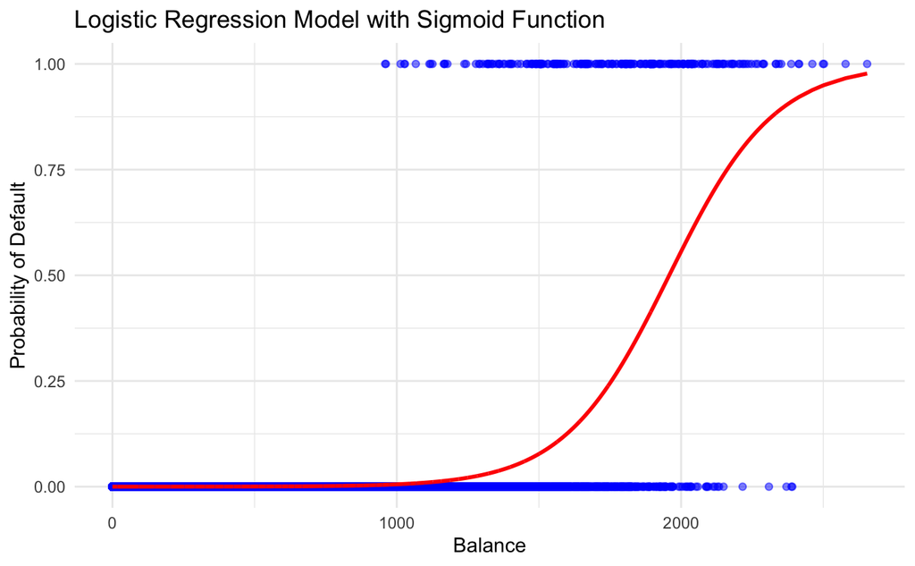

```r
library(ggplot2)
# first create a new column in the original df with predicted probabilities
train_data$predicted_prob2 <- glm.train_prob2

# create the plot to visualiza the sigmoid function
ggplot(train_data, aes(x = balance, y = as.numeric(default) - 1)) +
  geom_point(alpha = 0.5, color = 'blue') + # Data points
  geom_line(aes(y = predicted_prob2), color = 'red', linewidth = 1) + # Sigmoid curve
  labs(title = "Logistic Regression Model with Sigmoid Function",
       x = "Balance",
       y = "Probability of Default") +
  theme_minimal()
```

The model classifies customers with a credit card balance of just below 2,000 USD at the risk of default.

**Logistic regression with more than 1 variable**

Train the model and fit it to test:

```r
glm.fit3 <- glm(default ~ income + balance + student, data = train_data, family = binomial)

glm.train_prob3 <- predict(glm.fit3, type = "response", newdata = train_data)
glm.test_prob3 <- predict(glm.fit3, type = "response", newdata = test_data)

# Compute predictions for train set
glm.pred_train3 <- rep("No", nrow(train_data))
glm.pred_train3[glm.train_prob3 > 0.5] = "Yes"

# Compute predictions for test set
glm.pred_test3 <- rep("No", nrow(test_data))
glm.pred_test3[glm.test_prob3 > 0.5] = "Yes"
```

Now calculate the error rate for both:

```r
# Compute the in-sample error_rate and accuracy
error_rate_train3 <- mean(glm.pred_train3 != train_data$default)

# Compute the out-of-sample error_rate and accuracy
error_rate_test3 <- mean(glm.pred_test3 != test_data$default)


# Print the In-sample results
paste("In-sample error rate:", round(error_rate_train3, 5))
```

```
[1] "In-sample error rate: 0.02629"
```

```r
# Print the Out-of-sample results
paste("Out-of-sample error rate:", round(error_rate_test3, 5))
```

```
[1] "Out-of-sample error rate: 0.02767"
```

**Which model yielded the better results?**

We will use error rate as the loss function to decide on the best performing model among the three. Let’s put everything in a single dataframe.

```r
# Create data frames for each model
model_with_income <- data.frame(Model = "income",
                        train_error_rate = error_rate_train,
                        test_error_rate = error_rate_test)

model_with_balance <- data.frame(Model = "balance",
                                train_error_rate = error_rate_train2,
                                test_error_rate = error_rate_test2)

model_with_income_and_balance <- data.frame(Model = "income + balance + student",
                         train_error_rate = error_rate_train3,
                         test_error_rate = error_rate_test3)

# Combine the data frames into a single data frame
results_table <- do.call(rbind, list(model_with_income, model_with_balance, model_with_income_and_balance))

# Rename column headers
colnames(results_table) <- c("Model", "Train error rate", "Test error rate")

# Print the resulting data frame
print(results_table)
```

| Model | Train error rate | Test error rate |
| --- | --- | --- |
| income | 0.03300000 | 0.03400000 |
| balance | 0.02728571 | 0.02733333 |
| income + balance + student | 0.02628571 | 0.02766667 |